# Python tutorial: How to use the OpenAI API?

## Things you can do with the OpenAI API

In this tutorial, we will explore how to use the OpenAI API to perform various tasks using Python. The OpenAI API allows you to access powerful natural language processing models, such as ChatGPT, which can be used for a wide range of applications, including chatbots, language translation, text completion, and more.

We’ll look at just two different use cases: text completion and image generation, although it’s possible to do much more.

### Prerequisites

Before we begin, make sure you have the following prerequisites:

- Python 3.6 or higher installed
- OpenAI Python library (openai) installed. You can install it using pip:

```bash
pip install openai
```

## Libraries

```python
import openai #openAI api
import requests #get content of the generated image
import matplotlib.pyplot as plt #display generated image
from PIL import Image #create an image object
import io #make the image readable
print("hello world")
```

```
## hello world
```

## Define your API key

Since the use of the API is not free, you have to create an OpenAI account and add a credit card. However, the text completion is cheap (0.002$/1k token with GPT-3.5) and the image generation is ok if you don’t abuse of it (0.02$/image with DALLE). These values may change depending on the model you use.

```r
openai.api_key = "Your api key goes here"
```

## Text completion with GPT-3.5

### Define parameters for the model

They are mutliple parameters that you can modify when working with GPTs. It’s important to know what they do in order to customize as much as possible the way the model should behave in your use case. The description below are from the API reference. I only put the less context-specific parameters here and let you check the documentation if you are looking for something in particular.

- `temperature` (between 0 and 2, default 1): What sampling temperature to use, between 0 and 2. Higher values like 0.8 will make the output more random, while lower values like 0.2 will make it more focused and deterministic.
- `top_p` (between 0 and 1, default 1): An alternative to sampling with temperature, called nucleus sampling, where the model considers the results of the tokens with top_p probability mass. So 0.1 means only the tokens comprising the top 10% probability mass are considered.
- `n` (default 1): How many chat completion choices to generate for each input message.
- `presence_penalty` (between -2 and 2, default 0): Number between -2.0 and 2.0. Positive values penalize new tokens based on whether they appear in the text so far, increasing the model’s likelihood to talk about new topics.
- `frequency_penalty` (between -2 and 2, default 0): Number between -2.0 and 2.0. Positive values penalize new tokens based on their existing frequency in the text so far, decreasing the model’s likelihood to repeat the same line verbatim.

To get an idea of the importance of these parameters, I recommend you try out different combinations. Start with a simple, deterministic model, then modify it until the randomness is at its maximum.

NB: it is not recommended to set the `temperature` AND the `top_p` at the same time.

```python
#Define parameters for the model
temperature = 1.5
frequency_penalty = 0.5
presence_penalty = 0.5
model = "gpt-3.5-turbo" #you can choose another model
```

### Define the inputs

Now we want to define 2 different inputs. The `system_msg` must indicate how the model should behave. The `prompt` is just the message to which the model should *respond*.

```python
system_msg = """You're an AI assistant.
              All your answers start with
              'That is a good question my friend...'."""

prompt = "What are the main ideas behind quantum physics?"

messages=[{"role": "system","content": system_msg},
          {"role": "user","content": prompt}]
```

### Get the completion

```python
#call API
completion = openai.ChatCompletion.create(model=model,
                             messages=messages,
                             temperature=temperature,
                             frequency_penalty=frequency_penalty,
                             presence_penalty=presence_penalty)

#get output
output = completion["choices"][0]["message"]["content"]
```

```
## Input:
##   What are the main ideas behind quantum physics?
```

```
## Output:
##   That is a good question my friend.
## Quantum physics is the branch of physics that st
## udies the behavior of matter and energy at very tiny scales, such as atoms and subat
## omic particles. The main ideas behind quantum physics are probabilistic nature, part
## icle-wave duality, superposition, and quantum entanglement. Probabilistic nature mea
## ns that we can only predict the likelihood of finding a particle in a particular sta
## te instead of its exact position or velocity. Particle-wave duality refers to the fa
## ct that both particles and waves can exhibit traits of each other, depending on how
## they are observed. Superposition states that particles can exist in multiple states
## simultaneously until measured, and quantum entanglement suggests that particles can
## become interconnected even when far apart, leading to spooky action at a distance. T
## hese concepts revolutionize our understanding of the fundamental properties and beha
## vior of the bizarre world we exist in.
```

## Image generation with DALLE

### Define prompt and parameters

```python
#Define input
prompt = "high-quality image of the cutest cat in the world"
size = "1024x1024" #256x256, 512x512, or 1024x1024
n = 2 #number of image to generate
```

### Get the images

```python
#call API
response = openai.Image.create(
            prompt=prompt,
            n=n,
            size=size)

#get first image
image_url1 = response['data'][0]['url']
image_data1 = requests.get(image_url1).content
img1 = Image.open(io.BytesIO(image_data1))

#get second image
image_url2 = response['data'][1]['url']
image_data2 = requests.get(image_url2).content
img2 = Image.open(io.BytesIO(image_data2))
```

### Display the images

```
## (-0.5, 1023.5, 1023.5, -0.5)
```

```
## (-0.5, 1023.5, 1023.5, -0.5)
```

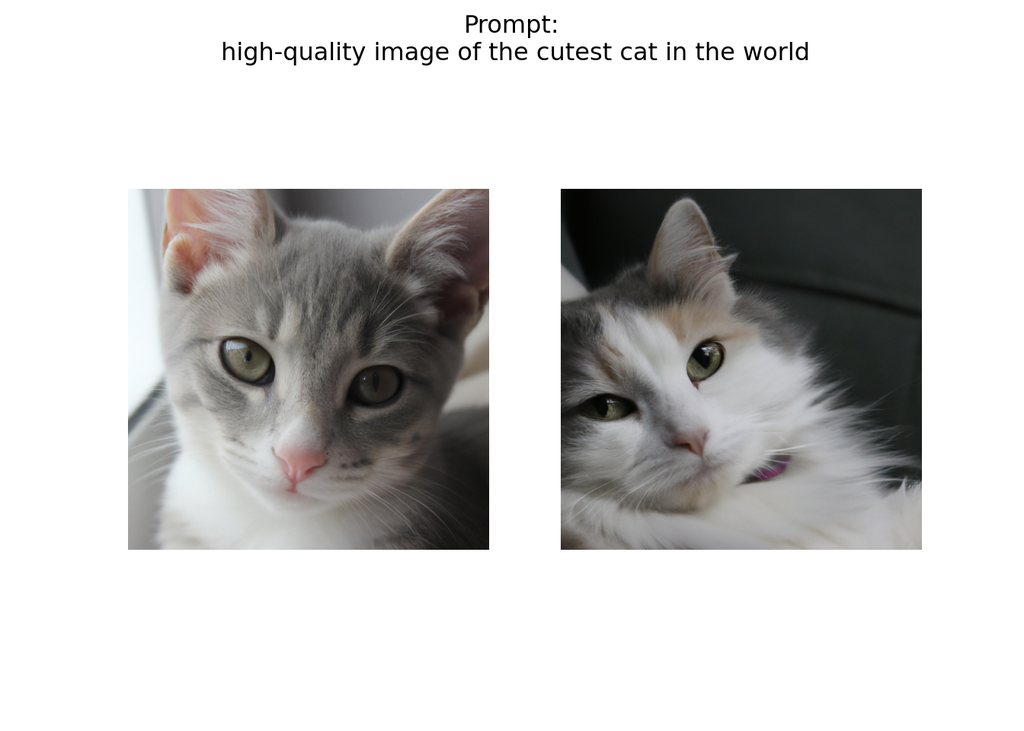